# Video Game Sales

Yong Fu Seong

2023-02-13

## About dataset

This dataset contains a list of video games with sales greater than 100,000 copies. It was generated by a scrape of vgchartz.com.

Fields include :

- Rank - Ranking of overall sales
- Name - The games name
- Platform - Platform of the games release (i.e. PC,PS4, etc.)
- Year - Year of the game’s release
- Genre - Genre of the game
- Publisher - Publisher of the game
- NA_Sales - Sales in North America (in millions)
- EU_Sales - Sales in Europe (in millions)
- JP_Sales - Sales in Japan (in millions)
- Other_Sales - Sales in the rest of the world (in millions)
- Global_Sales - Total worldwide sales

The script to scrape the data is available at https://github.com/GregorUT/vgchartzScrape.  
It is based on BeautifulSoup using Python.  
There are 16,598 records. 2 records were dropped due to incomplete information.

## Objectives

My objectives for this project is to uncover some key information through analysis of the dataset.  
These include:

- Number of games released per year
- Total sales by region
- Top 10 publishers ranked by Global Sales
- Top 10 Platform ranked by Global Sales
- Most popular genres ranked by Global Sales

## Setting up my environment

Setting up my environment by loading the following packages:

```r
install.packages("tidyverse")
install.packages("formattable")
library(tidyverse)
```

```r
library(readr)
library(tidyr)
library(dplyr)
library(ggplot2)
library(formattable)
```

## Prepare, view and clean the data

The csv file “vgsales.csv” is downloaded from this link https://www.kaggle.com/datasets/gregorut/videogamesales.

```r
df <- read_csv("vgsales.csv")
str(df)
```

```
## spc_tbl_ [16,598 × 11] (S3: spec_tbl_df/tbl_df/tbl/data.frame)
##  $ Rank        : num [1:16598] 1 2 3 4 5 6 7 8 9 10 ...
##  $ Name        : chr [1:16598] "Wii Sports" "Super Mario Bros." "Mario Kart Wii" "Wii Sports Resort" ...
##  $ Platform    : chr [1:16598] "Wii" "NES" "Wii" "Wii" ...
##  $ Year        : chr [1:16598] "2006" "1985" "2008" "2009" ...
##  $ Genre       : chr [1:16598] "Sports" "Platform" "Racing" "Sports" ...
##  $ Publisher   : chr [1:16598] "Nintendo" "Nintendo" "Nintendo" "Nintendo" ...
##  $ NA_Sales    : num [1:16598] 41.5 29.1 15.8 15.8 11.3 ...
##  $ EU_Sales    : num [1:16598] 29.02 3.58 12.88 11.01 8.89 ...
##  $ JP_Sales    : num [1:16598] 3.77 6.81 3.79 3.28 10.22 ...
##  $ Other_Sales : num [1:16598] 8.46 0.77 3.31 2.96 1 0.58 2.9 2.85 2.26 0.47 ...
##  $ Global_Sales: num [1:16598] 82.7 40.2 35.8 33 31.4 ...
##  - attr(*, "spec")=
##   .. cols(
##   ..   Rank = col_double(),
##   ..   Name = col_character(),
##   ..   Platform = col_character(),
##   ..   Year = col_character(),
##   ..   Genre = col_character(),
##   ..   Publisher = col_character(),
##   ..   NA_Sales = col_double(),
##   ..   EU_Sales = col_double(),
##   ..   JP_Sales = col_double(),
##   ..   Other_Sales = col_double(),
##   ..   Global_Sales = col_double()
##   .. )
##  - attr(*, "problems")=<externalptr>
```

```r
summary(df)
```

```
##       Rank           Name             Platform             Year
##  Min.   :    1   Length:16598       Length:16598       Length:16598
##  1st Qu.: 4151   Class :character   Class :character   Class :character
##  Median : 8300   Mode  :character   Mode  :character   Mode  :character
##  Mean   : 8301
##  3rd Qu.:12450
##  Max.   :16600
##     Genre            Publisher            NA_Sales          EU_Sales
##  Length:16598       Length:16598       Min.   : 0.0000   Min.   : 0.0000
##  Class :character   Class :character   1st Qu.: 0.0000   1st Qu.: 0.0000
##  Mode  :character   Mode  :character   Median : 0.0800   Median : 0.0200
##                                        Mean   : 0.2647   Mean   : 0.1467
##                                        3rd Qu.: 0.2400   3rd Qu.: 0.1100
##                                        Max.   :41.4900   Max.   :29.0200
##     JP_Sales         Other_Sales        Global_Sales
##  Min.   : 0.00000   Min.   : 0.00000   Min.   : 0.0100
##  1st Qu.: 0.00000   1st Qu.: 0.00000   1st Qu.: 0.0600
##  Median : 0.00000   Median : 0.01000   Median : 0.1700
##  Mean   : 0.07778   Mean   : 0.04806   Mean   : 0.5374
##  3rd Qu.: 0.04000   3rd Qu.: 0.04000   3rd Qu.: 0.4700
##  Max.   :10.22000   Max.   :10.57000   Max.   :82.7400
```

```r
head(df)
```

```
## # A tibble: 6 × 11
##    Rank Name         Platf…¹ Year  Genre Publi…² NA_Sa…³ EU_Sa…⁴ JP_Sa…⁵ Other…⁶
##   <dbl> <chr>        <chr>   <chr> <chr> <chr>     <dbl>   <dbl>   <dbl>   <dbl>
## 1     1 Wii Sports   Wii     2006  Spor… Ninten…    41.5   29.0     3.77    8.46
## 2     2 Super Mario… NES     1985  Plat… Ninten…    29.1    3.58    6.81    0.77
## 3     3 Mario Kart … Wii     2008  Raci… Ninten…    15.8   12.9     3.79    3.31
## 4     4 Wii Sports … Wii     2009  Spor… Ninten…    15.8   11.0     3.28    2.96
## 5     5 Pokemon Red… GB      1996  Role… Ninten…    11.3    8.89   10.2     1
## 6     6 Tetris       GB      1989  Puzz… Ninten…    23.2    2.26    4.22    0.58
## # … with 1 more variable: Global_Sales <dbl>, and abbreviated variable names
## #   ¹Platform, ²Publisher, ³NA_Sales, ⁴EU_Sales, ⁵JP_Sales, ⁶Other_Sales
```

The outputs from the str, summary and head functions reveal that all variables are formatted appropriately except for values in the ‘Year’ column which are formatted as character.

Let’s change the ‘Year’ column’s format from character to numeric value.

```r
df$Year <- as.numeric(df$Year)
```

Next, the following code will count how many NA values exist in each column.

```r
colSums(is.na(df))
```

```
##         Rank         Name     Platform         Year        Genre    Publisher
##            0            0            0          271            0            0
##     NA_Sales     EU_Sales     JP_Sales  Other_Sales Global_Sales
##            0            0            0            0            0
```

As a result, 271 NA values were detected in the ‘Year’ column which does not make sense. Therefore, I have filtered out those rows that consist of NA values in the ‘Year’ column.

```r
df <- filter(df, !is.na(Year))
```

I have also checked if any duplicate rows exist in this dataset. It turns out that no duplicate rows were identified. Although I have seen that some game names are repeated in different rows, these games are considered unique as they are available on different platforms.

```r
sum(duplicated(df))
```

```
## [1] 0
```

The sales columns will be used with some aggregate functions to deliver the result of the analysis. It is important to note that negative values in the sales columns are not logical and could affect the accuracy of the result. The below code was used to verify that there were no negative inputs in all the sales columns.

```r
colSums(df[7:11]<0)
```

```
##     NA_Sales     EU_Sales     JP_Sales  Other_Sales Global_Sales
##            0            0            0            0            0
```

Now we have a cleaned version of the dataset and let’s proceed to the analysis and visualization part.

## Analyze, Visualize and Findings

**Table 1 - Number of games released per year**

```r
tb1 <- df %>%
  group_by(Year) %>%
  summarise(number_of_games = n()) %>%
  arrange(Year)

tb1
```

```
## # A tibble: 39 × 2
##     Year number_of_games
##    <dbl>           <int>
##  1  1980               9
##  2  1981              46
##  3  1982              36
##  4  1983              17
##  5  1984              14
##  6  1985              14
##  7  1986              21
##  8  1987              16
##  9  1988              15
## 10  1989              17
## # … with 29 more rows
```

**Plot 1 - Line chart for number of games released per year**

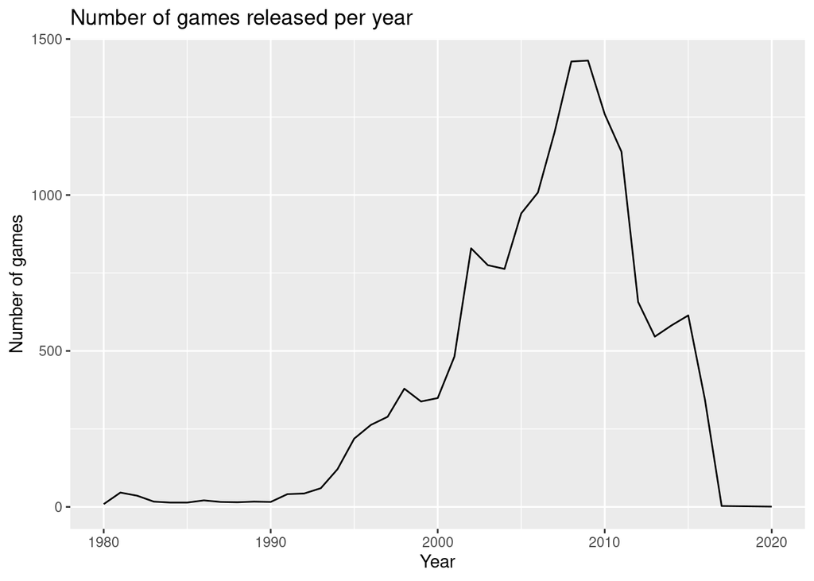

```r
p1 <- ggplot(tb1, aes(x=Year, y=number_of_games))+
  geom_line()+
  labs(title="Number of games released per year",
       y="Number of games")

p1
```

**Findings:**

The number of games had been growing since 1990 and reached a peak around 2010, but it has been a downtrend afterwards.  
**Table 2 - Total sales by region**

```r
tb2 <- df %>%
  summarise("NA" = sum(NA_Sales),
            EU = sum(EU_Sales),
            JP = sum(JP_Sales),
            Other = sum(Other_Sales))

tb2
```

```
## # A tibble: 1 × 4
##    `NA`    EU    JP Other
##   <dbl> <dbl> <dbl> <dbl>
## 1 4333. 2409. 1284.  789.
```

**Plot 2.1 - Pie Chart for total sales by region**

Here I had applied the percent function from the formattable package to create a vector of sales in percentage, which I then used to label the pie chart.

```r
tb2_sales_perc <- percent(as.double(tb2[1,])/sum(as.double(tb2[1,])))

tb2_sales_perc
```

```
## [1] 49.15% 27.33% 14.57% 8.95%
```

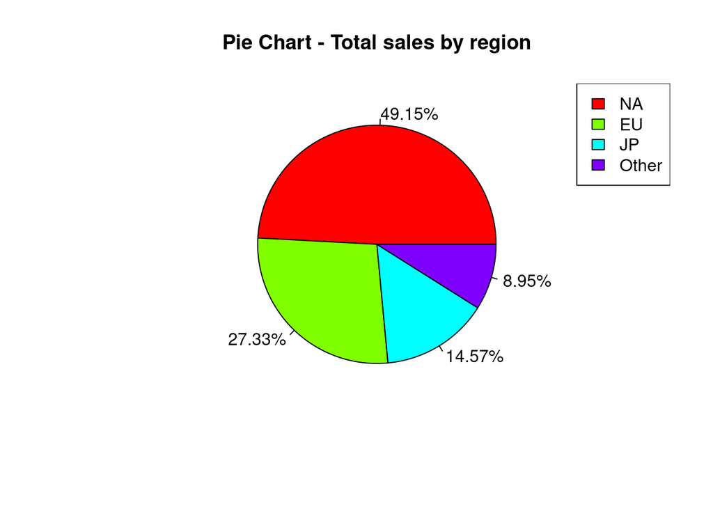

```r
pie(x=as.numeric(tb2[1,]), labels=tb2_sales_perc, main = "Pie Chart - Total sales by region", col=rainbow(4))
legend("topright", legend=colnames(tb2), fill=rainbow(4))
```

**Plot 2.2 - Vertical Bar Chart for total sales by region**

Unlike the pie chart, the bar chart with ggplot function requires the data to be in long format, so that I have restructured ‘tb2’ into ‘tb2_transpose’ to suit the ggplot function in order to create bar chart.

```r
tb2_transpose <- data.frame(region=colnames(tb2),sales=as.double(tb2[1,]))

tb2_transpose
```

```
##   region   sales
## 1     NA 4333.43
## 2     EU 2409.12
## 3     JP 1284.30
## 4  Other  789.01
```

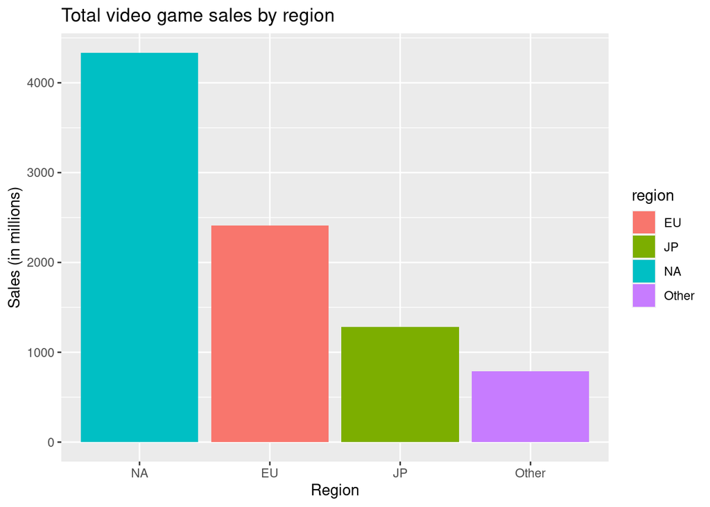

```r
p2_bar <- ggplot(tb2_transpose, aes(x=reorder(region, -sales), y=sales, fill=region))+
  geom_col()+
  labs(title="Total video game sales by region",
       x="Region",
       y="Sales (in millions)")

p2_bar
```

**Findings:**

North America is the largest video games market in the world accounting for almost 50% of the global sales, followed by Europe.  
**Table 3 - Top 10 Publishers ranked by Global Sales**

Table 3 was created to demonstrate the top 10 publishers ranked by global sales. This table also includes the market share in percentage for each publishers, number of games released, average sales per game, year of their first game release and the number of years since first game release for references.

```r
tb3 <- df %>%
  group_by(Publisher) %>%
  summarise(Global_Sales = sum(Global_Sales),
            market_share = percent(Global_Sales/sum(df$Global_Sales)),
            number_of_games = n(),
            avg_sales_per_game = Global_Sales / number_of_games,
            first_release = min(Year),
            years_since_first_release = 2023 - first_release) %>%
  arrange(-Global_Sales) %>%
  head(10)

tb3
```

```
## # A tibble: 10 × 7
##    Publisher                    Global…¹ marke…² numbe…³ avg_s…⁴ first…⁵ years…⁶
##    <chr>                           <dbl> <formt>   <int>   <dbl>   <dbl>   <dbl>
##  1 Nintendo                        1784. 20.23%      696   2.56     1983      40
##  2 Electronic Arts                 1093. 12.40%     1339   0.817    1992      31
##  3 Activision                       721. 8.18%       966   0.747    1980      43
##  4 Sony Computer Entertainment      607. 6.88%       682   0.890    1994      29
##  5 Ubisoft                          474. 5.37%       918   0.516    1995      28
##  6 Take-Two Interactive             399. 4.53%       412   0.969    1997      26
##  7 THQ                              340. 3.86%       712   0.478    1995      28
##  8 Konami Digital Entertainment     279. 3.16%       823   0.338    1986      37
##  9 Sega                             271. 3.07%       632   0.428    1982      41
## 10 Namco Bandai Games               254. 2.88%       928   0.273    1984      39
## # … with abbreviated variable names ¹Global_Sales, ²market_share,
## #   ³number_of_games, ⁴avg_sales_per_game, ⁵first_release,
## #   ⁶years_since_first_release
```

**Plot 3.1 - Horizontal Bar Chart for Top 10 Publishers by total sales**

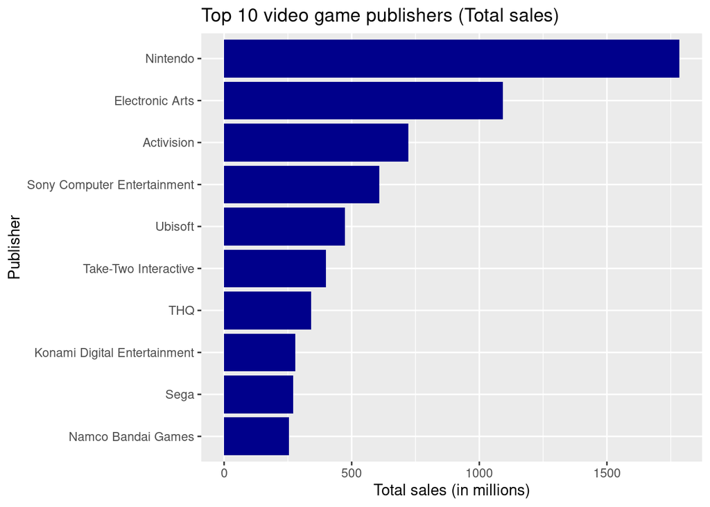

```r
p3_total_sales <- ggplot(tb3, aes(x=Global_Sales, y=reorder(Publisher, Global_Sales)))+
  geom_col(fill="darkblue")+
  labs(title="Top 10 video game publishers (Total sales)",
       x="Total sales (in millions)",
       y="Publisher")

p3_total_sales
```

**Plot 3.2 - Horizontal Bar Chart for Top 10 Publishers by average sales per game**

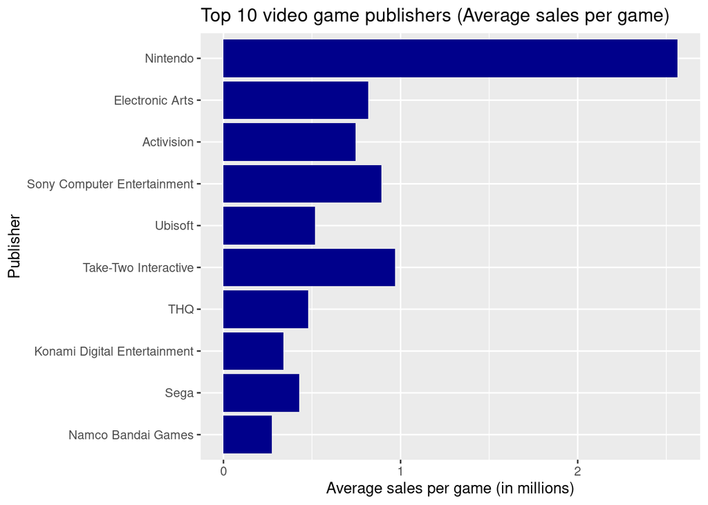

```r
p3_avg_sales <- ggplot(tb3, aes(x=avg_sales_per_game, y=reorder(Publisher, Global_Sales)))+
  geom_col(fill="darkblue")+
  labs(title="Top 10 video game publishers (Average sales per game)",
       x="Average sales per game (in millions)",
       y="Publisher")

p3_avg_sales
```

**Findings:**

Nintendo is the market leader in video games across the globe, followed by Electronic Arts and Activision. Moreover, Nintendo greatly outperformed its competitors with over 2 millions sales per game on average while none of its competitors has achieved 1 million of average sales per game. This implies that Nintendo is more focused on quality rather than quantity of the video games it launched.  
**Table 4 - Top 10 Platform ranked by Global Sales**

```r
tb4 <- df %>%
  group_by(Platform) %>%
  summarise(Global_Sales = sum(Global_Sales)) %>%
  arrange(-Global_Sales) %>%
  head(10)

tb4
```

```
## # A tibble: 10 × 2
##    Platform Global_Sales
##    <chr>           <dbl>
##  1 PS2             1233.
##  2 X360             970.
##  3 PS3              949.
##  4 Wii              910.
##  5 DS               819.
##  6 PS               727.
##  7 GBA              314.
##  8 PSP              292.
##  9 PS4              278.
## 10 PC               255.
```

**Plot 4 - Horizontal Bar Chart for Top 10 Platform by total sales**

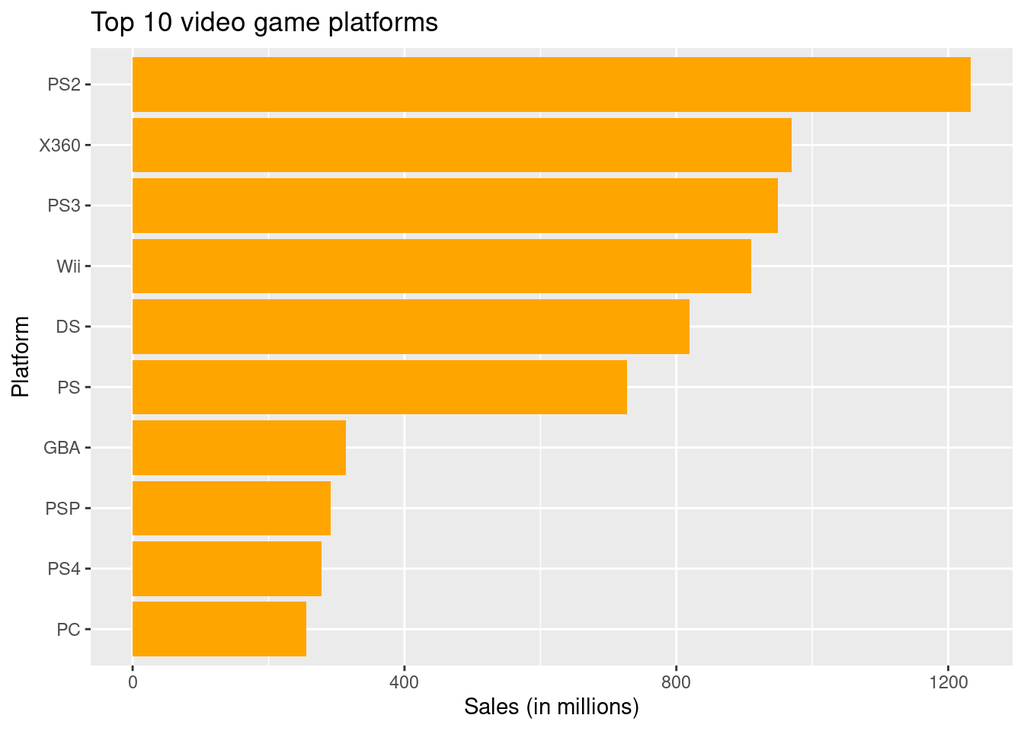

```r
p4 <- ggplot(tb4, aes(x=Global_Sales, y=reorder(Platform, Global_Sales)))+
  geom_col(fill="orange")+
  labs(title="Top 10 video game platforms",
       x="Sales (in millions)",
       y="Platform")

p4
```

**Findings:**

PS2 is the hottest among all video game platforms, followed by X360, PS3 and Wii.  
**Table 5 - Most Popular Genres ranked by Global Sales**

Table 5 showcases the ranking of video game genres based on the global sales. This table also comprises the sales breakdown for each region to illustrate the preferences of players in different regions.

```r
tb5 <- df %>%
  group_by(Genre) %>%
  summarise("NA" = sum(NA_Sales),
            EU = sum(EU_Sales),
            JP = sum(JP_Sales),
            Other = sum(Other_Sales),
            Global = sum(Global_Sales)) %>%
  arrange(-Global)

tb5
```

```
## # A tibble: 12 × 6
##    Genre         `NA`    EU    JP Other Global
##    <chr>        <dbl> <dbl> <dbl> <dbl>  <dbl>
##  1 Action       862.  516.  159.  185.   1723.
##  2 Sports       670.  371.  135.  133.   1309.
##  3 Shooter      575.  310.   38.2 102.   1026.
##  4 Role-Playing 326.  188.  350.   59.4   924.
##  5 Platform     446.  201.  131.   51.5   829.
##  6 Misc         402.  214.  107.   74.0   798.
##  7 Racing       357.  236.   56.6  76.7   727.
##  8 Fighting     221.  100    87.2  36.2   444.
##  9 Simulation   182.  113.   63.5  31.4   390.
## 10 Puzzle       122.   50.5  56.7  12.5   242.
## 11 Adventure    102.   63.8  52.0  16.7   235.
## 12 Strategy      67.9  44.9  49.1  11.2   173.
```

**Plot 5 - Horizontal Bar Chart for most popular video game genres by region**

The data in table 5 is in wide format which is not usable with ggplot function. Thus, the pivot_longer function was used to convert ‘tb5’ into the long format, which is then stored as ‘tb5_long’ to be used for plotting.

```r
tb5_long <- pivot_longer(data=tb5[1:5],
             cols=colnames(tb5[2:5]),
             names_to="region",
             values_to="sales")

tb5_long
```

```
## # A tibble: 48 × 3
##    Genre   region sales
##    <chr>   <chr>  <dbl>
##  1 Action  NA      862.
##  2 Action  EU      516.
##  3 Action  JP      159.
##  4 Action  Other   185.
##  5 Sports  NA      670.
##  6 Sports  EU      371.
##  7 Sports  JP      135.
##  8 Sports  Other   133.
##  9 Shooter NA      575.
## 10 Shooter EU      310.
## # … with 38 more rows
```

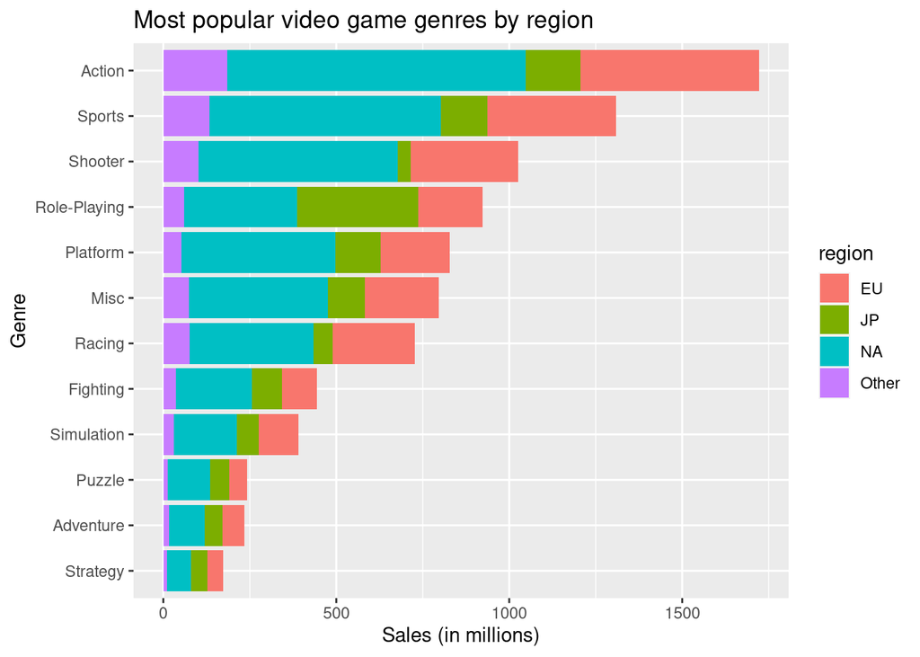

```r
p5 <- ggplot(tb5_long, aes(x=sales, y=Genre, fill=region))+
  geom_col()+
  scale_y_discrete(limits=rev(tb5$Genre))+
  labs(title="Most popular video game genres by region",
       x="Sales (in millions)")

p5
```

**Findings:**

Action game is the most popular genre across all regions except for Japan, followed by sports, shooter and role-playing games. There is an interesting fact that Japanese players are more inclined towards role-playing games as compared to other genres. Japanese players also differ from others by having a relatively lower sales in shooting games. This indicates that preferences of video game players vary by regions.